##### Now compute the singular values

From there, the singular values are just the square root of the eigenvalues

```r
eig$sing = sqrt(eig$values)
as.data.frame(eig$sing)
```

```
##        eig$sing
## 1  1.357802e+08
## 2  1.150748e+06
## 3  1.261265e+04
## 4  1.344507e+03
## 5  1.070591e+02
## 6  8.686314e+01
## 7  7.060580e+01
## 8  2.675405e+01
## 9  1.731018e+01
## 10 7.835383e+00
## 11 7.233339e+00
## 12 4.045820e+00
## 13 3.322479e+00
## 14 3.171077e+00
## 15 4.466967e-01
## 16 3.354413e-01
## 17 1.351244e-01
## 18 6.013561e-03
```

##### Construct the basis

Now we need to use our eigenvectors to construct a change of basis based on the highest singular value.

Specifically, we construct a change of basis into a basis starting with the eigenvector associated with the highest singular value.

Though, we can’t just use the eigenvectors as they are, we want our new basis to be orthonormal.

Having a normalized basis just makes things simpler, but there is a good reason for the basis to be orthogonal as well.

By having the basis vectors orthogonal to each other, we are effectively constructing a basis from our eigenvectors only using the parts of the eigenvectors that are uncorrelated from each other.

This leaves us with a basis that will describe our data only in terms of the parts that are uncorrelated from each other.

To do this, we need to preform the Gram-Schmidt process on our matrix of eigenvectors.

```r
if (!require("pracma")) {
    install.packages("pracma")
    library(pracma)
}
gs = gramSchmidt(A=eig$vectors)
as.data.frame(gs$Q)
```

```
##               V1            V2            V3            V4            V5
## 1   9.999747e-01  7.106755e-03  7.604406e-06  6.802394e-07 -6.233354e-08
## 2   7.106744e-03 -9.999698e-01 -3.130424e-03 -1.124480e-04 -8.987999e-06
## 3   3.607426e-07  9.843912e-06  3.276378e-02 -9.994192e-01 -2.709532e-03
## 4   1.896068e-09 -5.122782e-09  1.106982e-03 -8.730955e-03  2.520540e-01
## 5  -3.430546e-11 -1.780109e-07  9.222278e-05 -2.843458e-04 -1.681466e-02
## 6   7.280676e-08 -9.477645e-06  4.996314e-04 -8.698326e-04  1.633475e-01
## 7   1.463326e-05 -3.131528e-03  9.992240e-01  3.276006e-02 -2.040249e-02
## 8   1.467063e-07 -2.041324e-05  4.549534e-03 -1.159722e-03  3.273766e-01
## 9   3.804481e-07 -6.819751e-05  2.072662e-02  1.676540e-03  8.374077e-01
## 10  4.530182e-08 -7.420190e-07  7.442480e-04  6.143764e-04  6.261708e-02
## 11  4.643999e-09 -7.224704e-08  1.437989e-04 -7.031651e-05  3.603481e-02
## 12  1.356525e-07 -2.342991e-05  3.906615e-03 -2.534051e-03  2.925687e-01
## 13  3.822531e-09 -4.510087e-07  1.180019e-04  1.344362e-05  8.311393e-03
## 14  3.762095e-08 -5.662700e-06  6.642757e-04 -2.581299e-04  9.274100e-02
```

[output cut: 61 more lines]

```r
# check for othonormality
# sum all columns together and ensure they're all 1
colSums(gs$Q[,1:dim(gs$Q)[1]]^2)
```

```
##  [1] 1 1 1 1 1 1 1 1 1 1 1 1 1 1 1 1 1 1
```

```r
# so all the columns of Q are normalized
# now check if the columns are orthogonal
round(t(gs$Q[,1]) %*% gs$Q[,2], 15)
```

```
##      [,1]
## [1,]    0
```

```r
round(t(gs$Q[,7]) %*% gs$Q[,3], 15)
```

```
##      [,1]
## [1,]    0
```

```r
round(t(gs$Q[,18]) %*% gs$Q[,10], 15)
```

```
##      [,1]
## [1,]    0
```

##### Create a change of basis matrix

Now Q is an orthonormal basis of our data set.

So we need to find the change of basis matrix to convert our data into the new basis.

Our data set is currently in the standard basis, so we can use the identity matrix when creating our change of basis matrix via RREF.

```r
# form an augmented matrix
aug = cbind(gs$Q, diag(dim(gs$Q)[1]))
# convert to RREF
aug_r = rref(aug)
# extract the second half of the matrix to get our change of basis matrix
# take the columns starting from numcolumns(gs$Q)+1 to the end
P = aug_r[, (dim(gs$Q)[1] + 1): dim(aug_r)[2]]
```

Alternatively, instead of using the RREF method above, we could just…

```r
P2 = solve(gs$Q)
# there's some floating point imprecision, but measuring to the 13th digit is close enough for them to be equal.
as.data.frame(round(P,13) == round(P2,13))
```

```
##      V1   V2   V3   V4   V5   V6   V7   V8   V9  V10  V11  V12  V13  V14  V15
## 1  TRUE TRUE TRUE TRUE TRUE TRUE TRUE TRUE TRUE TRUE TRUE TRUE TRUE TRUE TRUE
## 2  TRUE TRUE TRUE TRUE TRUE TRUE TRUE TRUE TRUE TRUE TRUE TRUE TRUE TRUE TRUE
## 3  TRUE TRUE TRUE TRUE TRUE TRUE TRUE TRUE TRUE TRUE TRUE TRUE TRUE TRUE TRUE
## 4  TRUE TRUE TRUE TRUE TRUE TRUE TRUE TRUE TRUE TRUE TRUE TRUE TRUE TRUE TRUE
## 5  TRUE TRUE TRUE TRUE TRUE TRUE TRUE TRUE TRUE TRUE TRUE TRUE TRUE TRUE TRUE
## 6  TRUE TRUE TRUE TRUE TRUE TRUE TRUE TRUE TRUE TRUE TRUE TRUE TRUE TRUE TRUE
## 7  TRUE TRUE TRUE TRUE TRUE TRUE TRUE TRUE TRUE TRUE TRUE TRUE TRUE TRUE TRUE
## 8  TRUE TRUE TRUE TRUE TRUE TRUE TRUE TRUE TRUE TRUE TRUE TRUE TRUE TRUE TRUE
## 9  TRUE TRUE TRUE TRUE TRUE TRUE TRUE TRUE TRUE TRUE TRUE TRUE TRUE TRUE TRUE
## 10 TRUE TRUE TRUE TRUE TRUE TRUE TRUE TRUE TRUE TRUE TRUE TRUE TRUE TRUE TRUE
## 11 TRUE TRUE TRUE TRUE TRUE TRUE TRUE TRUE TRUE TRUE TRUE TRUE TRUE TRUE TRUE
## 12 TRUE TRUE TRUE TRUE TRUE TRUE TRUE TRUE TRUE TRUE TRUE TRUE TRUE TRUE TRUE
## 13 TRUE TRUE TRUE TRUE TRUE TRUE TRUE TRUE TRUE TRUE TRUE TRUE TRUE TRUE TRUE
## 14 TRUE TRUE TRUE TRUE TRUE TRUE TRUE TRUE TRUE TRUE TRUE TRUE TRUE TRUE TRUE
```

[output cut: 23 more lines]

##### Perform a change of basis

Now we have ‘P’, our change of basis matrix that will change the basis for the original data column vectors from the standard basis to our new, more useful basis.

So lets do that.

In general, for a change of basis, given basis ‘B’ and ‘C’, and change of basis matrix ‘P’ from basis ‘B’ to ‘C’

[X]C = P[X]B

Where [X]C is X in the C basis, and [X]B is X in the B basis.

So we need to multiply each column of our normalized data by ‘P’, or alternatively, we can just multiply the whole data matrix by ‘P’

```r
new_data = as.data.frame(c_data %*% t(P))
dim(new_data)
```

```
## [1] 179  18
```

```r
head(new_data)
```

```
##            V1            V2        V3        V4         V5         V6
## 1 31060814.33 -4.267682e+05 -1089.046 -77.13338  49.982585 -148.89758
## 2  3581768.92 -3.307288e+03  4440.034  21.90764  24.105844  -82.10200
## 3 32946185.91 -2.147661e+06 -1207.301 -62.87719 -22.305241  -68.78763
## 7    13477.51 -3.318498e+01  8607.884 149.57199 289.585876   66.59977
## 8    69109.56  1.366026e+01 11007.893 204.76164 302.437483  111.35627
## 9 39940488.58 -2.483127e+06  2839.205  68.57118  -8.898148  -23.64994
##            V7        V8         V9        V10        V11       V12         V13
## 1 -19.6479509  94.62839   9.255740 -2.7022998 11.7293902 16.017477 -12.7167070
## 2 -11.6644626 -36.52410   7.260611  6.7790857 -0.6294730 -3.315504  -0.3480189
## 3   4.5920168 -22.68162 -13.588736  7.5225056 -2.8718287 -2.574732  -4.2361991
## 7 -21.0599187   7.80183 -30.756739  2.7276239  5.5433329 10.690335  -6.8099246
## 8 -51.1470248  23.34857  -6.793551 -0.0286152 -2.5941324 -1.926062   4.0710499
## 9  -0.3345979 -31.53485   4.121647  4.4767660  0.6348825  1.015110  -0.3684653
##          V14         V15        V16         V17           V18
## 1 -1.4296007 -0.11799942 -0.4378892  0.10490776  0.0039501257
## 2 -4.3919372  0.56329369  0.6228932  0.06541574  0.0014461630
## 3 -5.5792145 -0.44752896 -0.4881746 -0.17673665 -0.0064856007
## 7  1.0510467  0.09979664 -0.0866475  0.05903751  0.0037029916
## 8 -2.1545295 -0.30364551 -0.2924974  0.01351778  0.0009931669
## 9  0.8290899  0.73797209  0.4570740 -0.03369564  0.0012427317
```

```r
if (!require("devtools")) {
    install.packages("devtools")
    library(devtools)
}
```

```r
if (!require("vqv/ggbiplot")) {
    install_github("vqv/ggbiplot")
    library(ggbiplot)
}
```

```
## Skipping install of 'ggbiplot' from a github remote, the SHA1 (f7ea76da) has not changed since last install.
##   Use `force = TRUE` to force installation
```

```r
# add the countries and regions back to the data
new_data = cbind(data$region, new_data)
new_data = cbind(data$country, new_data)
colnames(new_data) = c_names
head(new_data)
```

```
##              country                              region         pop
## 1       Afghanistan        ASIA (EX. NEAR EAST)          31060814.33
## 2           Albania  EASTERN EUROPE                       3581768.92
## 3           Algeria  NORTHERN AFRICA                     32946185.91
## 7          Anguilla              LATIN AMER. & CARIB        13477.51
## 8 Antigua & Barbuda              LATIN AMER. & CARIB        69109.56
## 9         Argentina              LATIN AMER. & CARIB     39940488.58
##            area pop_density coastline_ratio  migration infant_mortality
## 1 -4.267682e+05   -1089.046       -77.13338  49.982585       -148.89758
## 2 -3.307288e+03    4440.034        21.90764  24.105844        -82.10200
## 3 -2.147661e+06   -1207.301       -62.87719 -22.305241        -68.78763
## 7 -3.318498e+01    8607.884       149.57199 289.585876         66.59977
## 8  1.366026e+01   11007.893       204.76164 302.437483        111.35627
## 9 -2.483127e+06    2839.205        68.57118  -8.898148        -23.64994
##           gdp  literacy     phones     arable      crops     other     climate
## 1 -19.6479509  94.62839   9.255740 -2.7022998 11.7293902 16.017477 -12.7167070
## 2 -11.6644626 -36.52410   7.260611  6.7790857 -0.6294730 -3.315504  -0.3480189
## 3   4.5920168 -22.68162 -13.588736  7.5225056 -2.8718287 -2.574732  -4.2361991
## 7 -21.0599187   7.80183 -30.756739  2.7276239  5.5433329 10.690335  -6.8099246
## 8 -51.1470248  23.34857  -6.793551 -0.0286152 -2.5941324 -1.926062   4.0710499
## 9  -0.3345979 -31.53485   4.121647  4.4767660  0.6348825  1.015110  -0.3684653
##    birthrate   deathrate       agri    industry       service
## 1 -1.4296007 -0.11799942 -0.4378892  0.10490776  0.0039501257
## 2 -4.3919372  0.56329369  0.6228932  0.06541574  0.0014461630
## 3 -5.5792145 -0.44752896 -0.4881746 -0.17673665 -0.0064856007
## 7  1.0510467  0.09979664 -0.0866475  0.05903751  0.0037029916
## 8 -2.1545295 -0.30364551 -0.2924974  0.01351778  0.0009931669
## 9  0.8290899  0.73797209  0.4570740 -0.03369564  0.0012427317
```

Now here’s some plots of the data in the new basis, to be blunt, I really have no idea what conclusions to draw from these plots other than the fact that there is very little correlation between the variables

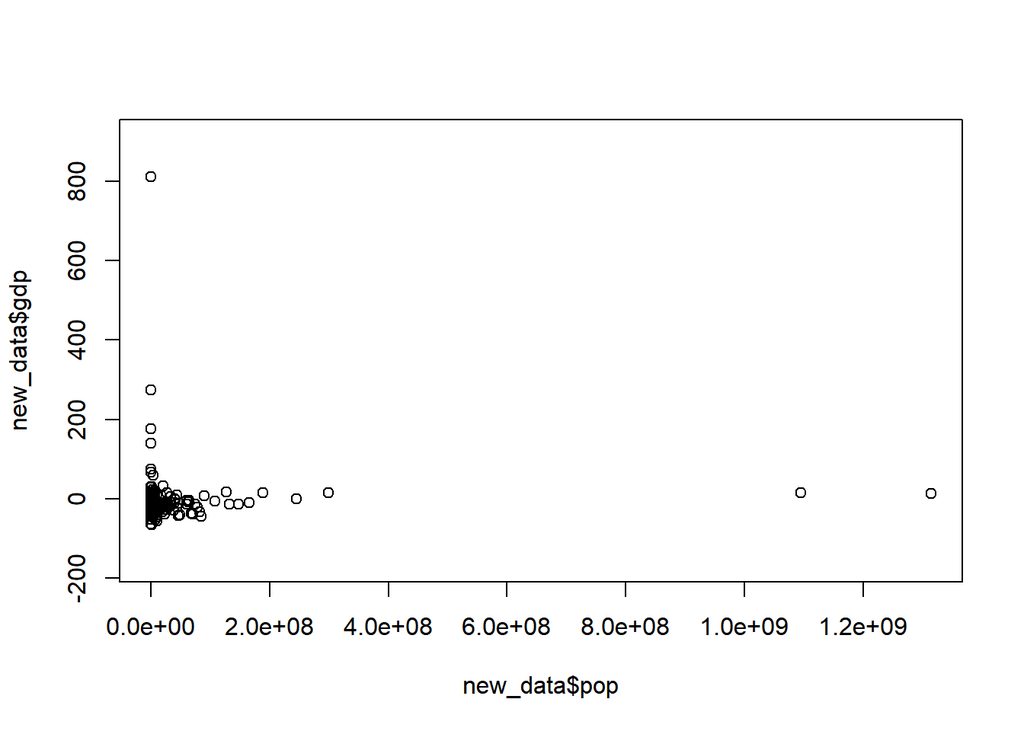

```r
plot(new_data$pop, new_data$gdp,
    xlim=c(min(new_data$pop)- 100, max(new_data$pop)+100),
    ylim=c(min(new_data$gdp)- 100, max(new_data$gdp)+100))
```

To contrast, here’s the same data in the standard basis.

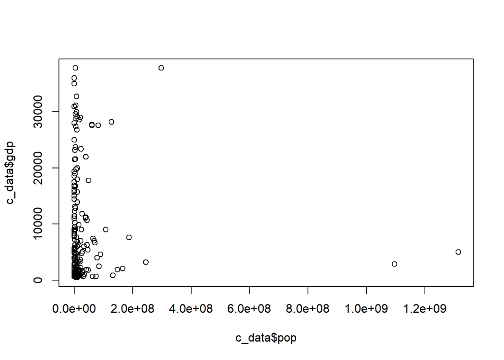

```r
c_data = as.data.frame(c_data)
plot(c_data$pop, c_data$gdp,
    xlim=c(min(c_data$pop)- 100, max(c_data$pop)+100),
    ylim=c(min(c_data$gdp)- 100, max(c_data$gdp) + 100))
```

Once more with other data…

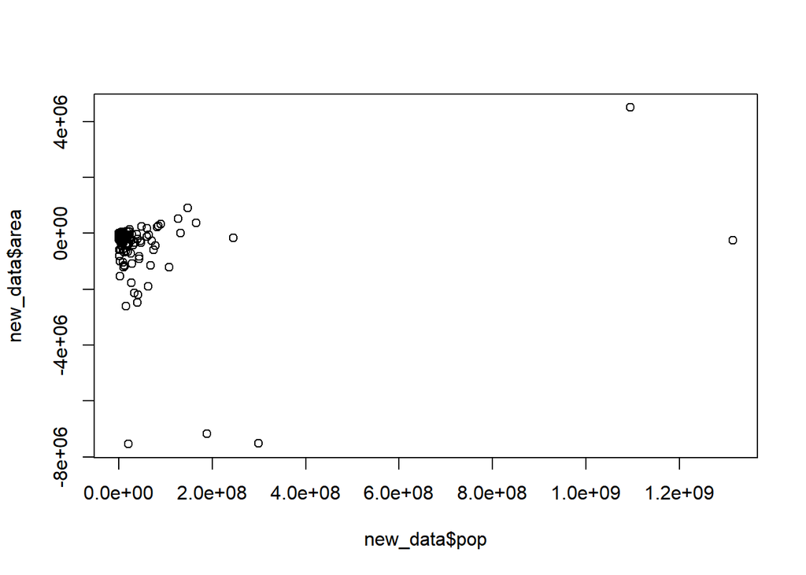

```r
plot(new_data$pop, new_data$area,
    xlim=c(min(new_data$pop)- 100, max(new_data$pop)+100),
    ylim=c(min(new_data$area)- 100, max(new_data$area)+100))
```

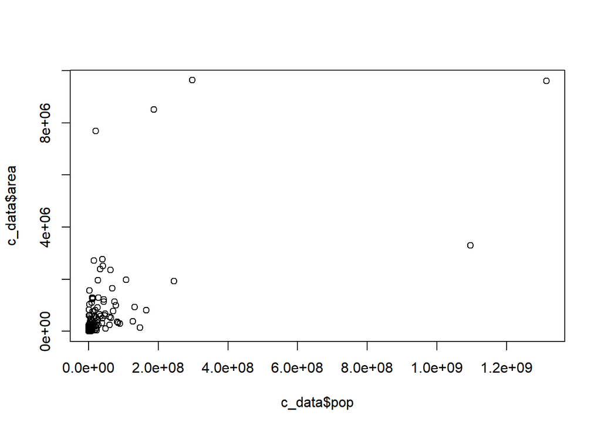

```r
plot(c_data$pop, c_data$area,
    xlim=c(min(c_data$pop)- 100, max(c_data$pop)+100),
    ylim=c(min(c_data$area)- 100, max(c_data$area)+100))
```

Here it almost looks like both plots are a reflection over the X-Axis, or rather, a negative vertical stretch of each other. There are a few minute differences in the graphs, like how the new data has more points actually crossing the X-Axis, but both graphs look close enough to each other to be interesting.

#### Part 2: Using ‘prcomp’ Function

```r
pca = prcomp(data[, to_center], scale = TRUE, center = TRUE)
summary(pca)
```

```
## Importance of components:
##                           PC1    PC2    PC3     PC4     PC5     PC6     PC7
## Standard deviation     2.3573 1.5989 1.3783 1.27473 1.20171 0.97416 0.92213
## Proportion of Variance 0.3087 0.1420 0.1055 0.09027 0.08023 0.05272 0.04724
## Cumulative Proportion  0.3087 0.4507 0.5563 0.64655 0.72678 0.77950 0.82675
##                            PC8     PC9   PC10    PC11    PC12    PC13    PC14
## Standard deviation     0.86063 0.74751 0.6841 0.61652 0.60213 0.53394 0.39998
## Proportion of Variance 0.04115 0.03104 0.0260 0.02112 0.02014 0.01584 0.00889
## Cumulative Proportion  0.86789 0.89894 0.9249 0.94605 0.96619 0.98203 0.99092
##                           PC15    PC16    PC17      PC18
## Standard deviation     0.31224 0.25553 0.02618 0.0003848
## Proportion of Variance 0.00542 0.00363 0.00004 0.0000000
## Cumulative Proportion  0.99633 0.99996 1.00000 1.0000000
```

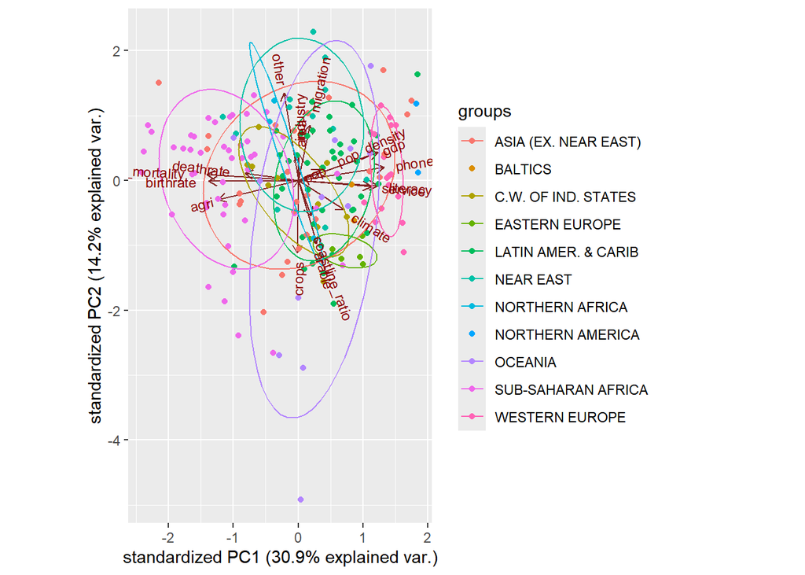

```r
ggbiplot(pca, groups = data$region, ellipse = TRUE)
```

This is pretty messy, and not really useful, so lets try trimming some of the data out, then trying again

```r
pca_data1 = as.data.frame(matrix(c(data$pop, data$area, data$pop_density, data$migration, data$gdp), nc=5, nr=length(data$pop)))
colnames(pca_data1) = c("pop", "area", "pop_density", "migration", "gdp")
pca2 = prcomp(pca_data1, scale = TRUE, center = TRUE)
summary(pca2)
```

```
## Importance of components:
##                           PC1    PC2    PC3    PC4     PC5
## Standard deviation     1.2734 1.2256 0.9367 0.7901 0.61219
## Proportion of Variance 0.3243 0.3004 0.1755 0.1248 0.07496
## Cumulative Proportion  0.3243 0.6247 0.8002 0.9250 1.00000
```

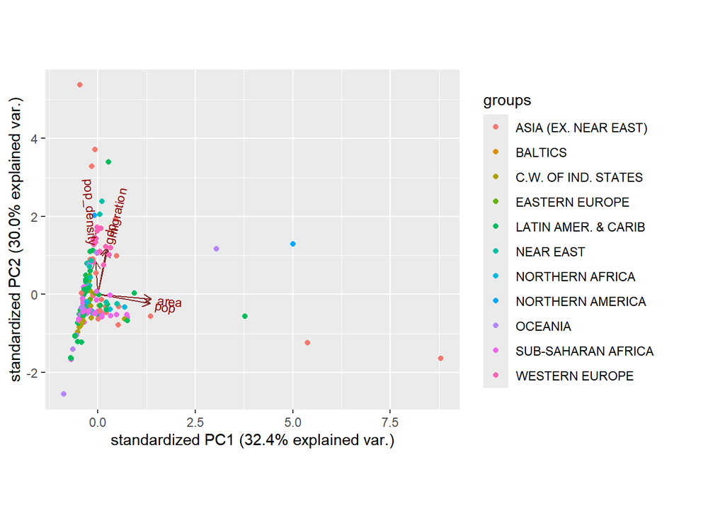

```r
ggbiplot(pca2, groups = data$region)
```

This is more readable, especially without the ellipses.

This graph gives us the projection of our variables onto the plane created by the ‘PC1’ and ‘PC2’ vectors.

From this graph, we can easily see there’s a relation between the vectors:

- ‘pop’ and ‘area’
- ‘gdp’ and ‘migration’
- and to a lesser extent, ‘pop_density’ and ‘gdp’/‘migration’

```r
pca_data2 = as.data.frame(matrix(c(data$pop, data$gdp), nc=2, nr=length(data$pop)))
colnames(pca_data2) = c("pop", "gdp")
pca3 = prcomp(pca_data2, scale = TRUE, center = TRUE)
summary(pca3)
```

```
## Importance of components:
##                           PC1    PC2
## Standard deviation     1.0167 0.9830
## Proportion of Variance 0.5168 0.4832
## Cumulative Proportion  0.5168 1.0000
```

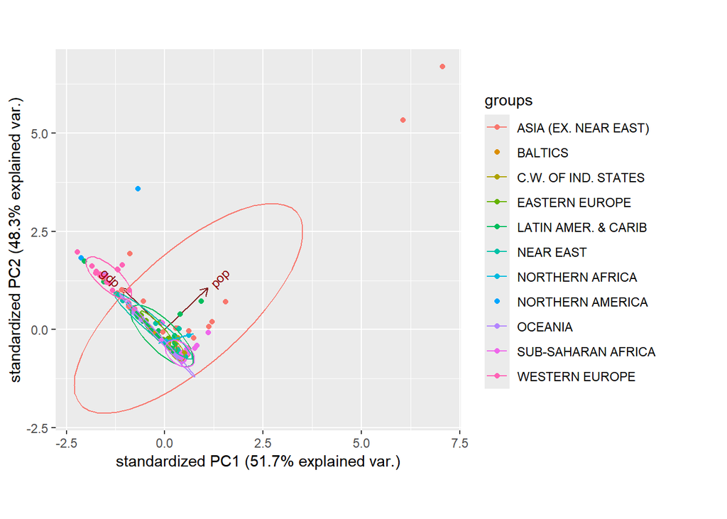

```r
ggbiplot(pca3, groups = data$region, ellipse = TRUE)
```

With a further subset of our data, we can see a similar result, the lack of correlation between ‘pop’ and ‘gdp’, though with a rotation of ~45 degrees.

But with a further reduced data set, it’s easier to interpret the data points graphically, or rather, it’s much easier to interpret the data points as a linear combination of the vectors on the graph.